# Biostatistics Homework

Suleimanov Shakir

2022-10-13

*Подгрузим библиотеку*

# Задача 1

**Рассчитаем математическое ожидание и дисперсию числа циклов терапии для дебюта заболевания:** M[X] = 1*0.5 + 2*0.5 = 1.5 D[X] = (1 - 0.5)*0.5 = 0.25

# Задача 2

**Построим таблицу распределения общего числа циклов терапии у рецидивировавших пациентов («дебютных» + «рецидивных»)**

```r
three_cycles <- 0.5*0.25
four_cycles <- 0.5*0.75 + 0.5*0.25
five_cycles <- 0.5*0.75

num_cycles <- c(three_cycles, four_cycles, five_cycles) %>%
  round(3) %>%
  matrix(ncol = 3) %>%
  as.data.frame()
colnames(num_cycles) <- c(3,4,5)
rownames(num_cycles) <- "Pr"
num_cycles
```

```
##        3   4     5
## Pr 0.125 0.5 0.375
```

**Рассчитаем математическое ожидание и дисперсию общего числа циклов терапии у рецидивировавших пациентов («дебютных» + «рецидивных»)**

M[X] = 3*0.125 + 4*0.5 + 5*0.375 = 4.25 D[X] = (3 - 4.25)^2*0.125 + (4 - 4.25)^2*0.5 + (5 - 4.25)^2*0.375 = 0.4375

# Задача 3

**Создадим таблицу данных, в которую положим значения SE, рассчитанные для соответствующего объема выборки**

```
##    N        SE
## 1 10 0.2091650
## 2 11 0.1994310
## 3 12 0.1909407
## 4 13 0.1834498
## 5 14 0.1767767
## 6 15 0.1707825
```

**Построим график теоретической зависимости стандартной ошибки (SE) при оценке среднего числа циклов от объема выборки N**

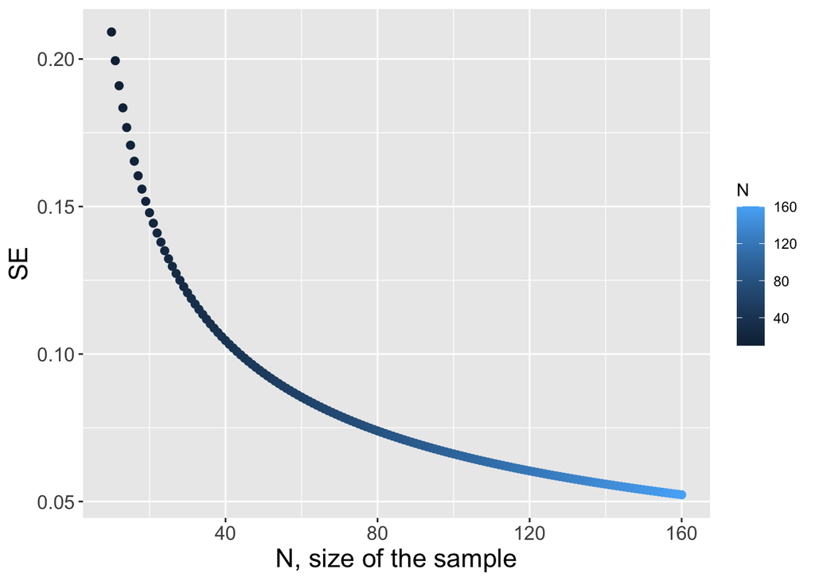

```r
ggplot(data = table, aes(x = N, y = SE))+
  geom_point(size = 2, aes(col = N))+
  xlab("N, size of the sample")+
  ylab("SE")+
  theme(axis.title.y = element_text(size = 16), axis.title.x = element_text(size = 16), axis.text.x = element_text(size=12), axis.text.y = element_text(size = 12), panel.background = element_rect())
```

# Задача 4

**Создадим функцию, которая будет считать нужные нам статистики**

```r
all_stat <- function(x){
  sd <- sd(x)
  se <- sd / sqrt(length(x))
  se_SE_ratio <- se / (SD/sqrt(length(x)))
  return(c(sd, se, se_SE_ratio))
}
```

**Создадим выборки с заданным объемом и рассчитаем для них необходимые статистические параметры**

```r
ten_patients <- sample(c(3:5), size = 10, replace = TRUE)
forty_patients <- sample(c(3:5), size = 40, replace = TRUE)
onehundredsixty_patients <- sample(c(3:5), size = 160, replace = TRUE)

stat_ten <- all_stat(ten_patients)
stat_forty <- all_stat(forty_patients)
stat_onehundredsixty <- all_stat(onehundredsixty_patients)
```

**Положим данные в таблицу**

```r
stat_table <- c(stat_ten, stat_forty, stat_onehundredsixty) %>%
  round(3) %>%
  matrix(ncol = 3, byrow = T) %>%
  as.data.frame()

colnames(stat_table) <- c("sd", "se", "se/SE")
rownames(stat_table) <- c("10 patients", "40 patients", "160 patients")
print(stat_table)
```

```
##                 sd    se se/SE
## 10 patients  0.843 0.267 1.275
## 40 patients  0.847 0.134 1.281
## 160 patients 0.783 0.062 1.185
```